# The weight of Pokémon species - Initial data analysis

Lara Lusa, Sam Manski, Marianne Huebner

July 2026

```r
knitr::opts_chunk$set(echo = TRUE, warning = FALSE, message = FALSE)
```

```r
library(dplyr)
library(naniar) #missing values
library(Hmisc)  #data summaries
library(kableExtra) #display tables
library(forcats)  #in tidyverse, to work with categorical variables
library(GGally) #includes ggpairs
library(pheatmap) #to plot heatmaps
library(gt) #for tables that use gt

library(dendextend) #coloring dendrograms
library(viridis) #colors
library(RColorBrewer) #colors

library(lme4) #linear mixed models

library(plotly)
library(reshape2)

library(tidyr)
library(ggrepel) # to add labels to busy graphs
library(scales) # to evaluate percentages in graphs
```

```r
color <- function(x, color="red") {
  if (knitr::is_latex_output()) {
    sprintf("\\textcolor{%s}{%s}", color, x)
  } else if (knitr::is_html_output()) {
    sprintf("<span style='color: %s;'>%s</span>", color,
      x)
  } else x
}

#can be used inline to change the color of the text, default is red
#`r color("try red color")`, `r color("try blue color", "blue")`

# specification used in Hmisc to print the tables
mu <- markupSpecs$html
```

[figure not shown]

[figure not shown]

[figure not shown]

[figure not shown]

[figure not shown]

[figure not shown]

[figure not shown]

[figure not shown]

[figure not shown]

[figure not shown]

```r
my.urls <- c("https://img.pokemondb.net/artwork/large/mewtwo.jpg", "https://img.pokemondb.net/artwork/large/eevee.jpg", "https://img.pokemondb.net/artwork/large/pikachu.jpg",
             "https://img.pokemondb.net/artwork/large/hypno.jpg",  "https://img.pokemondb.net/artwork/large/gengar.jpg",
               "https://img.pokemondb.net/artwork/large/psyduck.jpg", "https://img.pokemondb.net/artwork/large/mew.jpg",
             "https://img.pokemondb.net/artwork/large/charizard.jpg",  "https://img.pokemondb.net/artwork/large/palkia.jpg",
             "https://img.pokemondb.net/artwork/large/arceus.jpg"
             #,  "https://img.pokemondb.net/artwork/large/dialga.jpg"
               )

knitr::include_graphics(my.urls)
```

**Disclaimer**: Pokémon images are rendered in this document using references to online resources[Pokémon Database](https://urldefense.com/v3/__https://pokemondb.net__;!!HXCxUKc!3Y0TmfxsfOZjRx57xEEJjsLBabdNaT71a98fPLvaSldqnONM5fALBmMrFU-oEV2DcuABvlRlAMVckXbRNrkGPQ$), using URLs in the `https://img.pokemondb.net/artwork/` directory and are not stored locally.

## Comments on the IDA report

**COMMENT:** In the following of this document we describe the data screening steps of initial data analysis (IDA). The aim is to explore the data characteristics to gain knowledge about data properties, which enables informed statistical analysis and proper interpretation of the results. The IDA data screening plan was developed based on the checklist proposed by Heinze et al. for cross-sectional studies ([link to the paper](https://urldefense.com/v3/__https://www.researchsquare.com/article/rs-3580334/v1__;!!HXCxUKc!3Y0TmfxsfOZjRx57xEEJjsLBabdNaT71a98fPLvaSldqnONM5fALBmMrFU-oEV2DcuABvlRlAMVckXbcYBKu-g$)).

An IDA report typically focuses on presenting missing data, univariable, and multivariable descriptions. The research team would then discuss these IDA findings and decide on further actions. In this report a discussion of individual findings and potential consequences are included.

Boxes with a blue left border (**DEVIATION FROM SAP v1**) flag points where this report goes beyond, or deviates from, what was planned in the initial version of the statistical analysis plan (SAP v1) — for example, categorizations of variables decided during data screening. These deviations have been incorporated into the updated plan (SAP v2).

### To reproduce the content of this file on your computer**

Create a project in R (in RStudio, File -> New project), with two subfolders: Data and Report; save the Rmd version of this document in the Report folder and the data sets describing the properties of the Pokémon and the meta data in the Data folder. Set the working directory to project directory (menu: Session), working within a project makes importing data - working with relative paths - easier.

### Importing data

Data are saved in a text tab delimited file and are read them using the `read.delim` function from the Data folder.

```r
# local reading of data

pokemon <- read.delim("../Data/Pokemon_clean.tsv",
                      strip.white = TRUE, na.string =c(NA, ""),
                      blank.lines.skip = TRUE,
                      stringsAsFactors = FALSE)
```

```r
# Converting some variables into factors (PokemonPhase)
pokemon$PokemonPhase_5cat <- factor(pokemon$PokemonPhase_5cat, levels=c("Baby", "Base", "Phase1", "Phase2", "NotEvolving"))
pokemon$special_status <- factor(pokemon$special_status, levels=c("normal", "sub-legendary", "legendary",  "mythical"))
#arrange by pokedex number
pokemon <- arrange(pokemon, pokedex_number)

pokemon$gender_cat<-factor(pokemon$gender_cat, levels= c("Equal", "Mostly females", "Mostly males", "Genderless"), labels=c("Equal", "Mostly female", "Mostly male","Genderless"))
```

Data can be read also online - use the code below.

```r
# read data online
pokemon <- read.delim("https://stratosida.github.io/assets/Pokemon_clean.tsv",
                      strip.white = TRUE, na.string =c(NA, ""), blank.lines.skip = TRUE)

pokemon$PokemonPhase_5cat <- factor(pokemon$PokemonPhase_5cat, levels=c("Baby", "Base", "Phase1", "Phase2", "NotEvolving"))
pokemon$special_status <- factor(pokemon$special_status, levels=c("normal", "sub-legendary", "legendary",  "mythical"))
pokemon <- dplyr::arrange(pokemon, pokedex_number)

pokemon$gender_cat<-factor(pokemon$gender_cat, levels= c("Equal", "Mostly females", "Mostly males", "Genderless"), labels=c("Equal", "Mostly female", "Mostly male","Genderless"))
```

**COMMENT:**

Information about data sources and data cleaning and curation can be found in the data dictionary and in the statistical analysis plan. Data cleaning and data management was performed on this dataset.

## Research aim

The aim of this analysis project is to study the variability in the weight of Pokémon species.

Objective: to describe how differences in weight of the Pokémon species are associated with differences in height and other variables included in the dataset: evolutionary phase, gender proportion within species, attack/defense characteristics (base stats or their total), special status (mythical, legendary, sub-legendary, or normal), using a linear regression model. Base happiness and catch rate can also be considered as exploratory variables.

Hypothesis: There is a positive linear relationship between the height and weight of Pokémon species, even when various other characteristics of the species are taken into account.

Evolution phase and generation are **structural variables** for IDA purposes: in the multivariable descriptions, the main characteristics of the Pokémon species will be described stratifying the summaries by the levels of these variables. Gender is examined separately, as a dedicated subgroup analysis (see below), motivated by the missingness finding for Pokémon with unknown gender.

## Initial data analysis

The dataset includes 1025 different Pokémon, which are part of 541 different evolution families.

### Missing values

#### Prevalence

**RESULT:** Most of the variables in the dataset are complete.

The variables with missing values are: `percentage_male`, where missing values indicate that the species is genderless (which represents a category by itself, as some Pokémon do not have a gender), and second type of Pokémon (variable `type2`, it is possible that a Pokémon has only one type).

```r
tab1 <- pokemon %>%
  select(PokemonPhase_5cat, generation,  height_m, weight_kg, type1, type2, special_status,
         hp, attack, defense,   sp_attack, sp_defense, speed, total, catch_rate,    percentage_male,  base_happiness_8    ) %>%  miss_var_summary() %>%
  gt::gt() %>%
    gt::cols_label(
    variable = "Variable",
    n_miss = "Missing (count)",
    pct_miss = "Missing (%)"
  ) %>%
  gt::fmt_number(
    columns = c(pct_miss),
    decimals = 2
  )# Item (per variable) missingness

# to get scrollable gt tables
tab1 %>% gt::tab_options(container.height = px(200))
```

| Variable | Missing (count) | Missing (%) |
| --- | --- | --- |
| type2 | 489 | 47.7 |
| percentage_male | 154 | 15.0 |
| PokemonPhase_5cat | 0 | 0 |
| generation | 0 | 0 |
| height_m | 0 | 0 |
| weight_kg | 0 | 0 |
| type1 | 0 | 0 |
| special_status | 0 | 0 |
| hp | 0 | 0 |
| attack | 0 | 0 |
| defense | 0 | 0 |
| sp_attack | 0 | 0 |
| sp_defense | 0 | 0 |
| speed | 0 | 0 |
| total | 0 | 0 |
| catch_rate | 0 | 0 |
| base_happiness_8 | 0 | 0 |

**COMMENT:** Genderless Pokémon are a separate category by definition. Missing values do not indicate that the value is unknown to the researcher, but not defined. See also the univariable explorations for further considerations on the use of the variable percentage of male gender in modeling.

**CONSEQUENCE:** We define an arbitrary code value for missing gender (-1) that will help summarizing the information about genderless Pokémon (with blank value in male percentage). Summaries will be computed as for factors, as the number of different values among the non missing entries is small.

**DEVIATION FROM SAP v1:** SAP v1 anticipated that missing values in `percentage_male` would be categorized and their treatment assessed during IDA (Section 4.1), but did not specify the coding scheme. The choice of an arbitrary placeholder (-1) and the subsequent definition of the `gender_cat` categorical variable (see Univariable descriptions, below) were determined during this IDA and have been incorporated into SAP v2, Section 6.6.

**COMMENT:** Type 1 and type 2 should not be interpreted hierarchically. Namely, for a dual type Pokémon, excluding type 2 (rather than type 1) would be a completely arbitrary choice, as the order in which the types are listed does not matter. Our current project does not consider type as a potential explanatory variable. For projects that consider type as a potential explanatory variable, given the large proportion of single type Pokémon (=missing value for type 2), we would suggest that the type could be modeled using a binary variable to represent each type, rather than the two separate types. Also, all observed combinations between type 1 and type 2, regardless of order, could be considered as a new variable, but this would require a very large number of degrees of freedom to be used for modelling.

```r
pokemon$percentage_male[is.na(pokemon$percentage_male)] <- -1
```

**CONSEQUENCE:** Additional IDA summaries for Pokémon species that are single or dual type; we also provide some summaries by type, using the `is_(type)`, binary variables that indicate if a Pokémon is of that type. Single-type Pokémon are of one (pure) type, dual-types are of two types (the `dual_type` variable). The summary statistics for type 1 and type 2 are not reported.

**DEVIATION FROM SAP v1:** SAP v1 discussed 18 binary type indicators only as a possible modeling choice for projects that use type as an explanatory variable (Section 3, Type). Here type is not an explanatory variable; constructing the `is_(type)` indicators for descriptive IDA purposes (stratified summaries) was decided during IDA and has been incorporated into SAP v2, Table 1 (Type2 row) and Section 4.2.

#### Complete cases

To evaluate the impact of analyzing only Pokémon with known gender as would be the case in a complete case analysis), here we report tables that compare the main characteristics of Pokémon with known or unknown gender.

| Characteristics by known or unknown gender. | Characteristics by known or unknown gender. Known gender *N=871* | Characteristics by known or unknown gender. Genderless *N=154* |
| --- | --- | --- |
| PokemonPhase_5cat : Baby | 0.02 <sup>17</sup>⁄<sub>871</sub> | 0.00 <sup>0</sup>⁄<sub>154</sub> |
| Base | 0.37 <sup>326</sup>⁄<sub>871</sub> | 0.10 <sup>16</sup>⁄<sub>154</sub> |
| Phase1 | 0.39 <sup>336</sup>⁄<sub>871</sub> | 0.12 <sup>18</sup>⁄<sub>154</sub> |
| Phase2 | 0.12 <sup>105</sup>⁄<sub>871</sub> | 0.04 <sup>6</sup>⁄<sub>154</sub> |
| NotEvolving | 0.10 <sup>87</sup>⁄<sub>871</sub> | 0.74 <sup>114</sup>⁄<sub>154</sub> |
| height_m | 0.500 0.900 1.400 1.083 ± 0.971 | 0.600 1.500 2.375 1.949 ± 2.104 |
| special_status : normal | 0.98 <sup>856</sup>⁄<sub>871</sub> | 0.42 <sup>64</sup>⁄<sub>154</sub> |
| sub-legendary | 0.01 <sup>10</sup>⁄<sub>871</sub> | 0.27 <sup>41</sup>⁄<sub>154</sub> |
| legendary | 0.01 <sup>5</sup>⁄<sub>871</sub> | 0.17 <sup>26</sup>⁄<sub>154</sub> |
| mythical | 0.00 <sup>0</sup>⁄<sub>871</sub> | 0.15 <sup>23</sup>⁄<sub>154</sub> |
| hp | 50.0 65.0 80.0 67.5 ± 25.1 | 67.0 88.5 100.0 85.3 ± 29.8 |
| attack | 53.5 71.0 95.0 74.5 ± 28.5 | 73.2 95.0 120.0 94.6 ± 31.2 |
| defense | 50.0 65.0 85.0 68.8 ± 27.8 | 75.0 95.0 109.5 93.2 ± 29.0 |
| sp_attack | 45.0 60.0 85.0 65.6 ± 26.8 | 70.5 95.0 124.8 95.3 ± 32.5 |
| sp_defense | 50.0 65.0 80.0 66.5 ± 24.7 | 75.0 90.0 107.8 91.0 ± 28.0 |
| speed | 44.0 61.0 84.0 63.8 ± 26.8 | 62.0 90.0 105.8 86.3 ± 31.5 |
| total | 315 420 490 407 ± 101 | 506 570 600 546 ± 105 |
| catch_rate | 45.0 75.0 180.0 105.1 ± 74.8 | 3.0 10.0 45.0 37.9 ± 58.1 |

*a* *b* *c* represent the lower quartile *a*, the median *b*, and the upper quartile *c* for continuous variables. *x ± s* represents X ± 1 SD.

**RESULT:** Compared to others, genderless Pokémon are often not evolving, are considerably taller and stronger, are often mythical, sub-legendary or legendary.

**CONSEQUENCE:** A naive analysis that only uses the Pokémon with complete data would focus on a target population that is considerably different from the complete population. Note that these are not randomly missing data, since the variable is not defined for this category. Thus, imputation methods would not be appropriate.

### Univariable descriptions

The univariable descriptive statistics (at Pokémon level) are reported in a table, the variables are also presented graphically.

For easier data management, we define an additional dataset `pokemon_by_type` that facilitates the summarization of the Pokémon by types (see code below).

```r
pokemon_by_type <- pokemon %>% pivot_longer(cols = c("type1", "type2"), values_drop_na = TRUE, names_to = NULL, values_to = "type")
```

#### Summary statistic in table formats

pokemon.to.describe  
34 Variables 1025 Observations

weight_kg

| n | missing | distinct | Info | Mean | Gmd | .05 | .10 | .25 | .50 | .75 | .90 | .95 |
| --- | --- | --- | --- | --- | --- | --- | --- | --- | --- | --- | --- | --- |
| 1025 | 0 | 481 | 1 | 66.96 | 89.59 | 1.2 | 3.0 | 8.5 | 28.0 | 70.0 | 162.3 | 260.0 |

lowest : 0.1 0.2 0.3 0.4 0.5 , highest: 820 888 920 950 999.9

height_m

| n | missing | distinct | Info | Mean | Gmd | .05 | .10 | .25 | .50 | .75 | .90 | .95 |
| --- | --- | --- | --- | --- | --- | --- | --- | --- | --- | --- | --- | --- |
| 1025 | 0 | 54 | 0.997 | 1.213 | 0.9738 | 0.3 | 0.3 | 0.5 | 1.0 | 1.5 | 2.0 | 2.8 |

lowest : 0.1 0.2 0.3 0.4 0.5 , highest: 8.8 9.2 12 14.5 20

PokemonPhase_5cat

| n | missing | distinct |
| --- | --- | --- |
| 1025 | 0 | 5 |

```
 Value             Baby        Base      Phase1      Phase2 NotEvolving
 Frequency           17         342         354         111         201
 Proportion       0.017       0.334       0.345       0.108       0.196
```

generation

| n | missing | distinct | Info | Mean | Gmd |
| --- | --- | --- | --- | --- | --- |
| 1025 | 0 | 9 | 0.986 | 4.741 | 3.014 |

```
 Value          1     2     3     4     5     6     7     8     9
 Frequency    151   100   135   107   156    72    88    96   120
 Proportion 0.147 0.098 0.132 0.104 0.152 0.070 0.086 0.094 0.117
```

For the frequency table, variable is rounded to the nearest 0

percentage_male

| n | missing | distinct | Info | Mean | Gmd |
| --- | --- | --- | --- | --- | --- |
| 1025 | 0 | 8 | 0.761 | 46.37 | 27.24 |

```
 Value       -1.0   0.0  12.5  25.0  50.0  75.0  87.5 100.0
 Frequency    154    37     2    25   631    19   131    26
 Proportion 0.150 0.036 0.002 0.024 0.616 0.019 0.128 0.025
```

For the frequency table, variable is rounded to the nearest 0

special_status

| n | missing | distinct |
| --- | --- | --- |
| 1025 | 0 | 4 |

```
 Value             normal sub-legendary     legendary      mythical
 Frequency            920            51            31            23
 Proportion         0.898         0.050         0.030         0.022
```

hp

| n | missing | distinct | Info | Mean | Gmd | .05 | .10 | .25 | .50 | .75 | .90 | .95 |
| --- | --- | --- | --- | --- | --- | --- | --- | --- | --- | --- | --- | --- |
| 1025 | 0 | 107 | 0.998 | 70.18 | 28.12 | 36.2 | 40.0 | 50.0 | 68.0 | 85.0 | 100.0 | 111.0 |

lowest : 1 10 20 25 28 , highest: 190 200 223 250 255

attack

| n | missing | distinct | Info | Mean | Gmd | .05 | .10 | .25 | .50 | .75 | .90 | .95 |
| --- | --- | --- | --- | --- | --- | --- | --- | --- | --- | --- | --- | --- |
| 1025 | 0 | 117 | 0.999 | 77.52 | 33.88 | 30 | 40 | 55 | 75 | 100 | 120 | 130 |

lowest : 5 10 15 20 22 , highest: 147 150 160 165 181

defense

| n | missing | distinct | Info | Mean | Gmd | .05 | .10 | .25 | .50 | .75 | .90 | .95 |
| --- | --- | --- | --- | --- | --- | --- | --- | --- | --- | --- | --- | --- |
| 1025 | 0 | 108 | 0.998 | 72.51 | 32.02 | 35 | 40 | 50 | 70 | 90 | 110 | 125 |

lowest : 5 10 15 20 23 , highest: 180 184 200 211 230

sp_attack

| n | missing | distinct | Info | Mean | Gmd | .05 | .10 | .25 | .50 | .75 | .90 | .95 |
| --- | --- | --- | --- | --- | --- | --- | --- | --- | --- | --- | --- | --- |
| 1025 | 0 | 113 | 0.999 | 70.08 | 33.37 | 30.0 | 35.0 | 47.0 | 65.0 | 90.0 | 111.6 | 125.0 |

lowest : 10 15 20 21 23 , highest: 145 150 151 154 173

sp_defense

| n | missing | distinct | Info | Mean | Gmd | .05 | .10 | .25 | .50 | .75 | .90 | .95 |
| --- | --- | --- | --- | --- | --- | --- | --- | --- | --- | --- | --- | --- |
| 1025 | 0 | 103 | 0.998 | 70.21 | 29.49 | 31.2 | 40.0 | 50.0 | 67.0 | 86.0 | 105.0 | 120.0 |

lowest : 20 23 25 30 31 , highest: 142 150 154 200 230

speed

| n | missing | distinct | Info | Mean | Gmd | .05 | .10 | .25 | .50 | .75 | .90 | .95 |
| --- | --- | --- | --- | --- | --- | --- | --- | --- | --- | --- | --- | --- |
| 1025 | 0 | 119 | 0.999 | 67.19 | 32.53 | 25 | 30 | 45 | 65 | 88 | 105 | 115 |

lowest : 5 10 13 15 20 , highest: 145 150 151 160 200

total

| n | missing | distinct | Info | Mean | Gmd | .05 | .10 | .25 | .50 | .75 | .90 | .95 |
| --- | --- | --- | --- | --- | --- | --- | --- | --- | --- | --- | --- | --- |
| 1025 | 0 | 207 | 1 | 427.7 | 128.6 | 250 | 280 | 325 | 450 | 508 | 570 | 600 |

lowest : 175 180 185 190 194 , highest: 660 670 680 690 720

catch_rate

| n | missing | distinct | Info | Mean | Gmd | .05 | .10 | .25 | .50 | .75 | .90 | .95 |
| --- | --- | --- | --- | --- | --- | --- | --- | --- | --- | --- | --- | --- |
| 1025 | 0 | 37 | 0.97 | 95.01 | 81.87 | 3 | 25 | 45 | 60 | 140 | 225 | 255 |

lowest : 3 5 6 10 15 , highest: 205 220 225 235 255

base_happiness_8

| n | missing | distinct | Info | Mean | Gmd |
| --- | --- | --- | --- | --- | --- |
| 1025 | 0 | 8 | 0.459 | 46.89 | 12.79 |

```
 Value          0    20    35    50    70    90   100   140
 Frequency     80     3    73   835     3     5    15    11
 Proportion 0.078 0.003 0.071 0.815 0.003 0.005 0.015 0.011
```

For the frequency table, variable is rounded to the nearest 0

dual_type

| n | missing | distinct |
| --- | --- | --- |
| 1025 | 0 | 2 |

```
 Value        Dual Single
 Frequency     536    489
 Proportion  0.523  0.477
```

is_water

| n | missing | distinct | Info | Sum | Mean | Gmd |
| --- | --- | --- | --- | --- | --- | --- |
| 1025 | 0 | 2 | 0.383 | 154 | 0.1502 | 0.2556 |

is_normal

| n | missing | distinct | Info | Sum | Mean | Gmd |
| --- | --- | --- | --- | --- | --- | --- |
| 1025 | 0 | 2 | 0.334 | 131 | 0.1278 | 0.2232 |

is_grass

| n | missing | distinct | Info | Sum | Mean | Gmd |
| --- | --- | --- | --- | --- | --- | --- |
| 1025 | 0 | 2 | 0.323 | 126 | 0.1229 | 0.2158 |

is_flying

| n | missing | distinct | Info | Sum | Mean | Gmd |
| --- | --- | --- | --- | --- | --- | --- |
| 1025 | 0 | 2 | 0.285 | 109 | 0.1063 | 0.1903 |

is_psychic

| n | missing | distinct | Info | Sum | Mean | Gmd |
| --- | --- | --- | --- | --- | --- | --- |
| 1025 | 0 | 2 | 0.271 | 103 | 0.1005 | 0.181 |

is_bug

| n | missing | distinct | Info | Sum | Mean | Gmd |
| --- | --- | --- | --- | --- | --- | --- |
| 1025 | 0 | 2 | 0.245 | 92 | 0.08976 | 0.1636 |

is_poison

| n | missing | distinct | Info | Sum | Mean | Gmd |
| --- | --- | --- | --- | --- | --- | --- |
| 1025 | 0 | 2 | 0.226 | 84 | 0.08195 | 0.1506 |

is_fire

| n | missing | distinct | Info | Sum | Mean | Gmd |
| --- | --- | --- | --- | --- | --- | --- |
| 1025 | 0 | 2 | 0.221 | 82 | 0.08 | 0.1473 |

is_ground

| n | missing | distinct | Info | Sum | Mean | Gmd |
| --- | --- | --- | --- | --- | --- | --- |
| 1025 | 0 | 2 | 0.203 | 75 | 0.07317 | 0.1358 |

is_rock

| n | missing | distinct | Info | Sum | Mean | Gmd |
| --- | --- | --- | --- | --- | --- | --- |
| 1025 | 0 | 2 | 0.201 | 74 | 0.0722 | 0.1341 |

is_dark

| n | missing | distinct | Info | Sum | Mean | Gmd |
| --- | --- | --- | --- | --- | --- | --- |
| 1025 | 0 | 2 | 0.198 | 73 | 0.07122 | 0.1324 |

is_fighting

| n | missing | distinct | Info | Sum | Mean | Gmd |
| --- | --- | --- | --- | --- | --- | --- |
| 1025 | 0 | 2 | 0.198 | 73 | 0.07122 | 0.1324 |

is_dragon

| n | missing | distinct | Info | Sum | Mean | Gmd |
| --- | --- | --- | --- | --- | --- | --- |
| 1025 | 0 | 2 | 0.191 | 70 | 0.06829 | 0.1274 |

is_electric

| n | missing | distinct | Info | Sum | Mean | Gmd |
| --- | --- | --- | --- | --- | --- | --- |
| 1025 | 0 | 2 | 0.188 | 69 | 0.06732 | 0.1257 |

is_steel

| n | missing | distinct | Info | Sum | Mean | Gmd |
| --- | --- | --- | --- | --- | --- | --- |
| 1025 | 0 | 2 | 0.178 | 65 | 0.06341 | 0.1189 |

is_ghost

| n | missing | distinct | Info | Sum | Mean | Gmd |
| --- | --- | --- | --- | --- | --- | --- |
| 1025 | 0 | 2 | 0.178 | 65 | 0.06341 | 0.1189 |

is_fairy

| n | missing | distinct | Info | Sum | Mean | Gmd |
| --- | --- | --- | --- | --- | --- | --- |
| 1025 | 0 | 2 | 0.176 | 64 | 0.06244 | 0.1172 |

is_ice

| n | missing | distinct | Info | Sum | Mean | Gmd |
| --- | --- | --- | --- | --- | --- | --- |
| 1025 | 0 | 2 | 0.144 | 52 | 0.05073 | 0.09641 |

**COMMENT:** The `is_(type)*` variables are binary variables that indicate if a Pokémon is of that type. Single-type Pokémon are of one (pure) type, dual-types are of two types (the `dual_type` variable. The summary statistics for type 1 and type 2 are not reported.

Additionally, we provide a table that summarizes the descriptive statistics, as it would be usually presented in a paper.

| Overall characteristics. | Overall characteristics. *N=1025* |
| --- | --- |
| weight_kg | 8.5 28.0 70.0 67.0 ± 121.2 |
| height_m | 0.50 1.00 1.50 1.21 ± 1.25 |
| PokemonPhase_5cat : Baby | 0.02 <sup>17</sup>⁄<sub>1025</sub> |
| Base | 0.33 <sup>342</sup>⁄<sub>1025</sub> |
| Phase1 | 0.35 <sup>354</sup>⁄<sub>1025</sub> |
| Phase2 | 0.11 <sup>111</sup>⁄<sub>1025</sub> |
| NotEvolving | 0.20 <sup>201</sup>⁄<sub>1025</sub> |
| generation : 1 | 0.15 <sup>151</sup>⁄<sub>1025</sub> |
| 2 | 0.10 <sup>100</sup>⁄<sub>1025</sub> |
| 3 | 0.13 <sup>135</sup>⁄<sub>1025</sub> |
| 4 | 0.10 <sup>107</sup>⁄<sub>1025</sub> |
| 5 | 0.15 <sup>156</sup>⁄<sub>1025</sub> |
| 6 | 0.07 <sup>72</sup>⁄<sub>1025</sub> |
| 7 | 0.09 <sup>88</sup>⁄<sub>1025</sub> |
| 8 | 0.09 <sup>96</sup>⁄<sub>1025</sub> |
| 9 | 0.12 <sup>120</sup>⁄<sub>1025</sub> |
| special_status : normal | 0.90 <sup>920</sup>⁄<sub>1025</sub> |
| sub-legendary | 0.05 <sup>51</sup>⁄<sub>1025</sub> |
| legendary | 0.03 <sup>31</sup>⁄<sub>1025</sub> |
| mythical | 0.02 <sup>23</sup>⁄<sub>1025</sub> |
| hp | 50.0 68.0 85.0 70.2 ± 26.6 |
| attack | 55.0 75.0 100.0 77.5 ± 29.8 |
| defense | 50.0 70.0 90.0 72.5 ± 29.3 |
| sp_attack | 47.0 65.0 90.0 70.1 ± 29.7 |
| sp_defense | 50.0 67.0 86.0 70.2 ± 26.6 |
| speed | 45.0 65.0 88.0 67.2 ± 28.7 |
| total | 325 450 508 428 ± 113 |
| catch_rate | 45.0 60.0 140.0 95.0 ± 76.4 |
| percentage_male : -1 | 0.15 <sup>154</sup>⁄<sub>1025</sub> |
| 0 | 0.04 <sup>37</sup>⁄<sub>1025</sub> |
| 12.5 | 0.00 <sup>2</sup>⁄<sub>1025</sub> |
| 25 | 0.02 <sup>25</sup>⁄<sub>1025</sub> |
| 50 | 0.62 <sup>631</sup>⁄<sub>1025</sub> |
| 75 | 0.02 <sup>19</sup>⁄<sub>1025</sub> |
| 87.5 | 0.13 <sup>131</sup>⁄<sub>1025</sub> |
| 100 | 0.03 <sup>26</sup>⁄<sub>1025</sub> |
| base_happiness_8 : 0 | 0.08 <sup>80</sup>⁄<sub>1025</sub> |
| 20 | 0.00 <sup>3</sup>⁄<sub>1025</sub> |
| 35 | 0.07 <sup>73</sup>⁄<sub>1025</sub> |
| 50 | 0.81 <sup>835</sup>⁄<sub>1025</sub> |
| 70 | 0.00 <sup>3</sup>⁄<sub>1025</sub> |
| 90 | 0.00 <sup>5</sup>⁄<sub>1025</sub> |
| 100 | 0.01 <sup>15</sup>⁄<sub>1025</sub> |
| 140 | 0.01 <sup>11</sup>⁄<sub>1025</sub> |
| is_water | 0.15 <sup>154</sup>⁄<sub>1025</sub> |
| is_normal | 0.13 <sup>131</sup>⁄<sub>1025</sub> |
| is_grass | 0.12 <sup>126</sup>⁄<sub>1025</sub> |
| is_flying | 0.11 <sup>109</sup>⁄<sub>1025</sub> |
| is_psychic | 0.1 <sup>103</sup>⁄<sub>1025</sub> |
| is_bug | 0.09 <sup>92</sup>⁄<sub>1025</sub> |
| is_poison | 0.08 <sup>84</sup>⁄<sub>1025</sub> |
| is_fire | 0.08 <sup>82</sup>⁄<sub>1025</sub> |
| is_ground | 0.07 <sup>75</sup>⁄<sub>1025</sub> |
| is_rock | 0.07 <sup>74</sup>⁄<sub>1025</sub> |
| is_dark | 0.07 <sup>73</sup>⁄<sub>1025</sub> |
| is_fighting | 0.07 <sup>73</sup>⁄<sub>1025</sub> |
| is_dragon | 0.07 <sup>70</sup>⁄<sub>1025</sub> |
| is_electric | 0.07 <sup>69</sup>⁄<sub>1025</sub> |
| is_steel | 0.06 <sup>65</sup>⁄<sub>1025</sub> |
| is_ghost | 0.06 <sup>65</sup>⁄<sub>1025</sub> |
| is_fairy | 0.06 <sup>64</sup>⁄<sub>1025</sub> |
| is_ice | 0.05 <sup>52</sup>⁄<sub>1025</sub> |

*a* *b* *c* represent the lower quartile *a*, the median *b*, and the upper quartile *c* for continuous variables. *x ± s* represents X ± 1 SD.

**RESULTS - NUMERICAL VARIABLES:** Most of the numerical variables have positively asymmetric distributions, most notably height and weight, as it can be observed comparing the median and the mean values, or interpreting the interquartile ranges. This aspect is explored further with graphical displays presented below.

Percentage of male gender and base happiness have few distinct values and might be discretized without substantial loss of information. For gender, this is helpful also for taking into account the problem of missing values in percentage male, as the Pokémon with undefined gender can be grouped in their own category.

**CONSEQUENCES:** We define a new variable `gender_cat` that discretizes the percentage of male gender; the categories are: genderless, mostly females (0-49 percentage males), equal, mostly males (51-100 percentage males). We also define a new variable `happiness_cat` that discretizes the base happiness; the categories are: Unhappy (<50), Normal (50),Happy (>50). (Note that the for convenience the code to generate these variables is provided below, but the dataset used in this project already includes this variables).

In regression modeling it is sensible to present regression coefficients of base stats that refer to a meaningful difference (for example, in units of 10 or 20).

**DEVIATION FROM SAP v1:** The categorization of `percentage_male` into `gender_cat` (4 levels) and of `base_happiness_8` into `happiness_cat` (3 levels) was not specified in SAP v1; both variables and their categorization schemes were defined during IDA, based on the limited number of distinct values observed. This has been incorporated into SAP v2, Section 6.6, and both are used as categorical explanatory variables in the regression model (Section 4.2).

```r
pokemon$gender_cat <- pokemon$gender_unknown
pokemon$gender_cat[pokemon$gender_unknown==1] = "Genderless"
pokemon$gender_cat[pokemon$percentage_male>=0] = "Mostly females"
pokemon$gender_cat[pokemon$percentage_male==50] = "Equal"
pokemon$gender_cat[pokemon$percentage_male>50] = "Mostly males"

pokemon$gender_cat <- relevel(factor(pokemon$gender_cat), ref="Equal")
```

```r
pokemon$happiness_cat <- pokemon$base_happiness_8
pokemon$happiness_cat[pokemon$base_happiness_8==50] = "Normal"
pokemon$happiness_cat[pokemon$base_happiness_8<50] = "Unhappy"
pokemon$happiness_cat[pokemon$base_happiness_8>50] = "Happy"
pokemon$happiness_cat <- relevel(factor(pokemon$happiness_cat), ref ="Normal")
```

We summarize the descriptive statistics with the new categorical variables.

| Overall characteristics - new categorized variables. | Overall characteristics - new categorized variables. *N=1025* |
| --- | --- |
| gender_cat : Equal | 0.62 <sup>631</sup>⁄<sub>1025</sub> |
| Mostly female | 0.06 <sup>64</sup>⁄<sub>1025</sub> |
| Mostly male | 0.17 <sup>176</sup>⁄<sub>1025</sub> |
| Genderless | 0.15 <sup>154</sup>⁄<sub>1025</sub> |
| happiness_cat : Happy | 0.03 <sup>34</sup>⁄<sub>1025</sub> |
| Normal | 0.81 <sup>835</sup>⁄<sub>1025</sub> |
| Unhappy | 0.15 <sup>156</sup>⁄<sub>1025</sub> |

**RESULTS - CATEGORICAL VARIABLES** Generation 1 and 5 included the most Pokémon, 6 the least. Most Pokémon are Base or Phase 1, baby Pokémon is a rare category, most evolutionary chains include 2 species. There are 18 Pokémon types, water is the most common type among all Pokémon, while the most common type for dual-type Pokémon is flying. Approximately 50% of Pokémon are single-type (type 2 missing) and 50% are dual-type. Most Pokémon species have equal gender representations (62%), and about 15% of Pokémon species are genderless.

Only 31 Pokémon species are legendary, 51 Pokémon species are sub-legendary, and only 23 are mythical.

Some categorical variables have categories with few observed Pokémon, like baby phase in the evolution phase, or happy Pokémon for the happiness variable, or mythical Pokémon for the variable indicating the special status of Pokémon.

**CONSEQUENCES:** In regression modeling we can use reference categories: Base for evolution phase, normal happiness, equal gender, normal for special status variable.

#### Graphical displays

The numerical variables are displayed using histograms with small classes (to identify specific features of the data, like digit preference or values that are very common), for some variables also larger classes are used (to display more clearly the shape of the distributions). The number (and proportion) of Pokémon classified by any type is presented with a graph (each Pokémon is classified in 1 or 2 types).

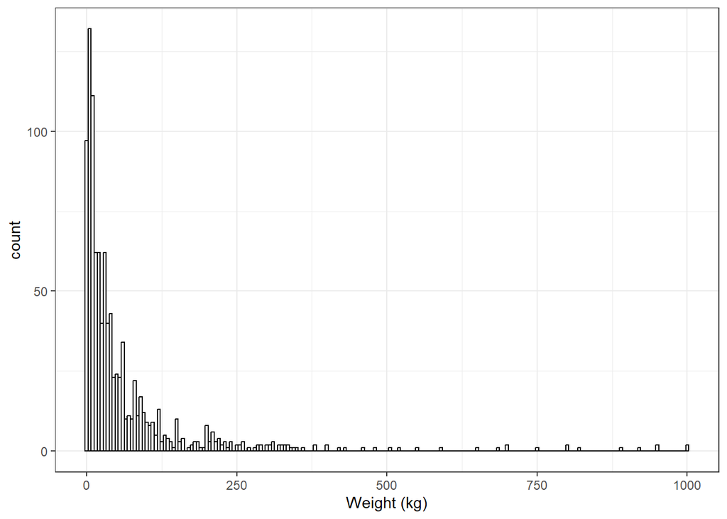

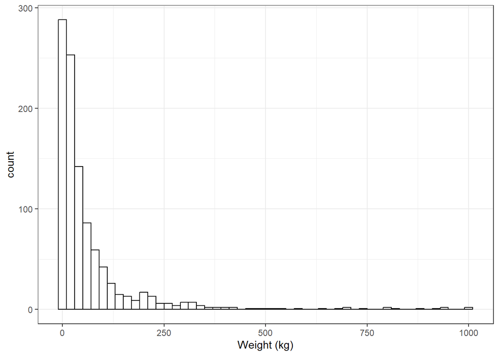

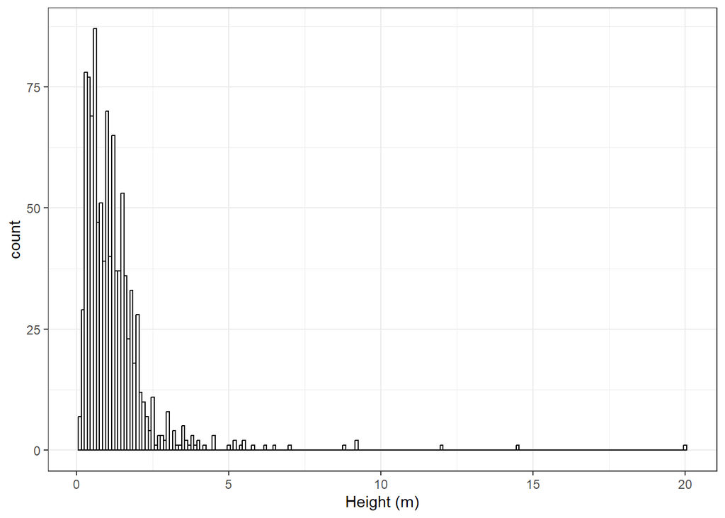

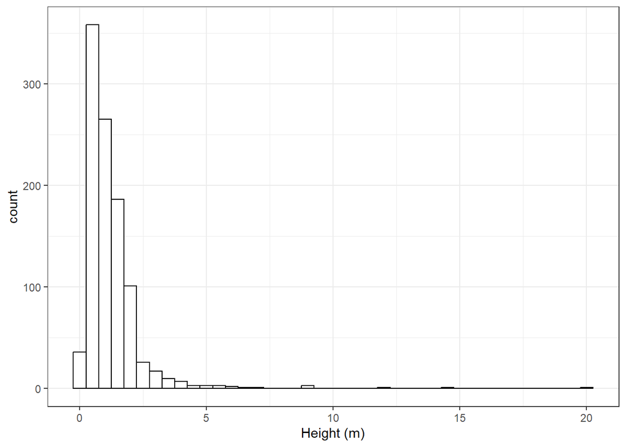

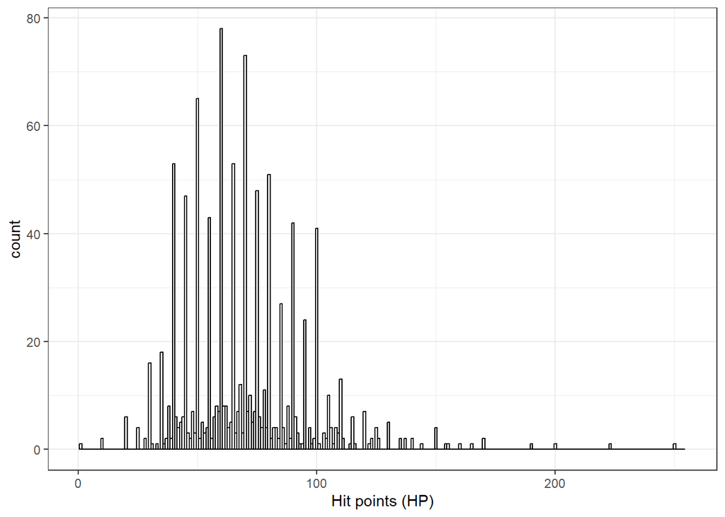

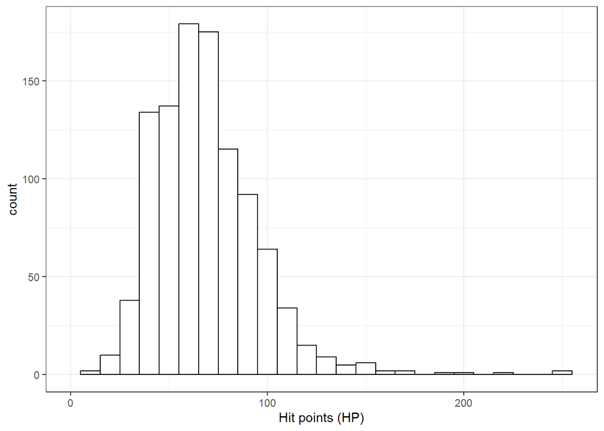

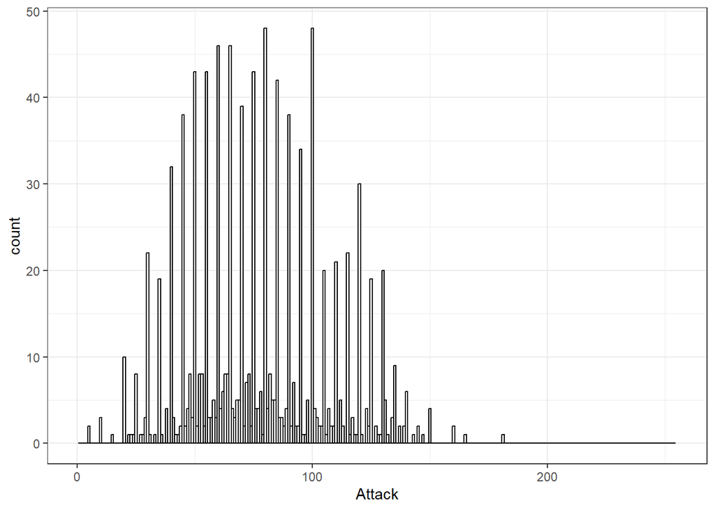

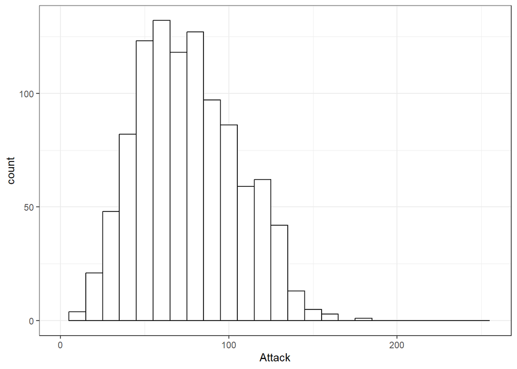

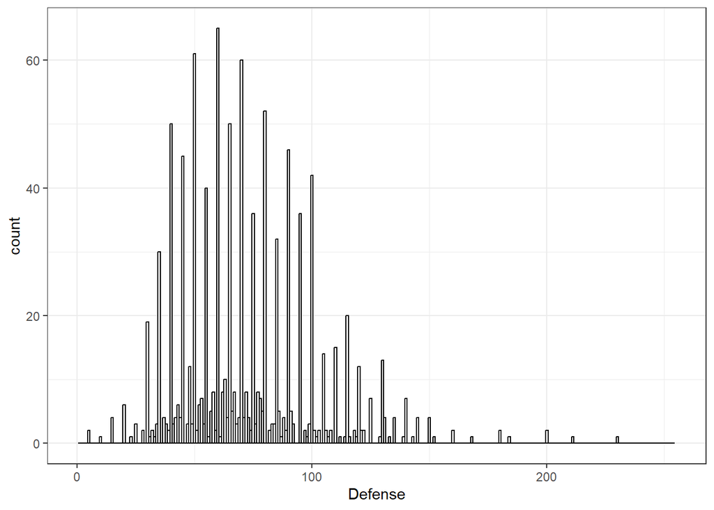

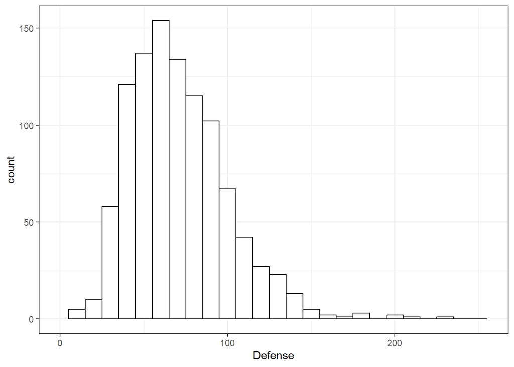

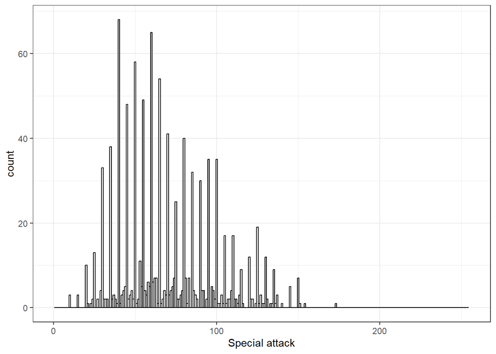

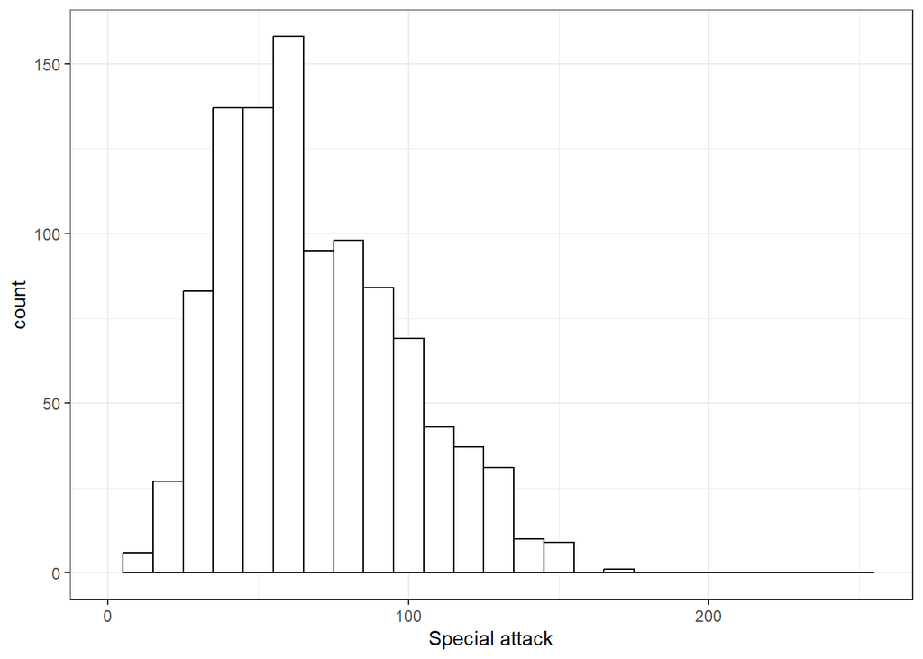

[9 more figures not shown]

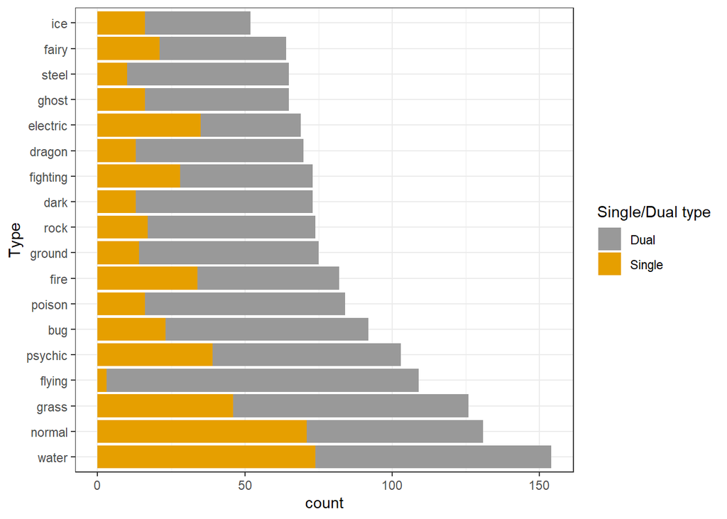

```r
cbPalette <- c("#999999", "#E69F00", "#56B4E9", "#009E73", "#F0E442", "#0072B2", "#D55E00", "#CC79A7")
ggplot(pokemon_by_type, aes(forcats::fct_infreq(type)))+geom_bar(aes(fill = dual_type)) +coord_flip()+scale_fill_manual(values=cbPalette)+labs(x = "Type", fill = "Single/Dual type") + theme_bw()
```

**RESULTS:** The graphical displays confirm that most of the numerical variables have positively asymmetric distributions, most notably height and weight. The variables related to attacks are positively asymmetric, values ending with 0 are very common, numbers multiple of 0.1 are common for height; the total number of points has a bimodal/trimodal distribution.

**CONSEQUENCES:** It is not sensible to assume that the numerical variables follow a Gaussian distribution, log transformation might be advisable, especially for the outcome variable of weight, and height.

We also plot log2-transformed of height and weight with normal qqplots to assess normality after transformation.

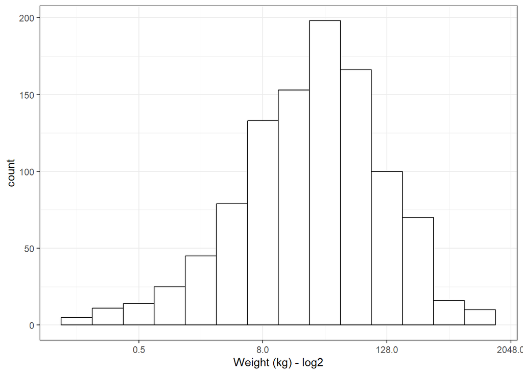

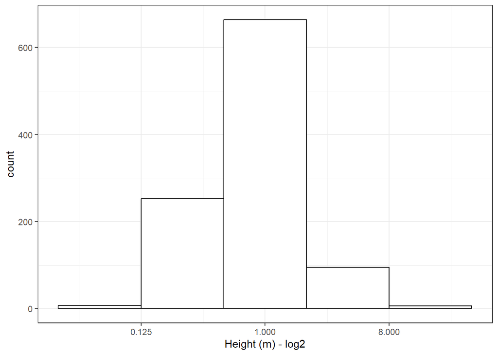

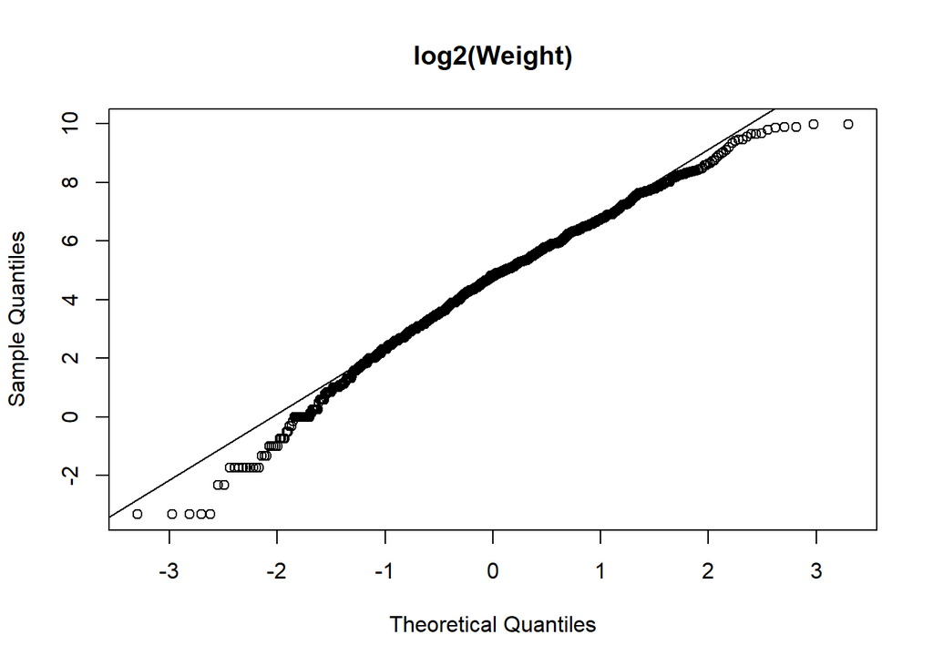

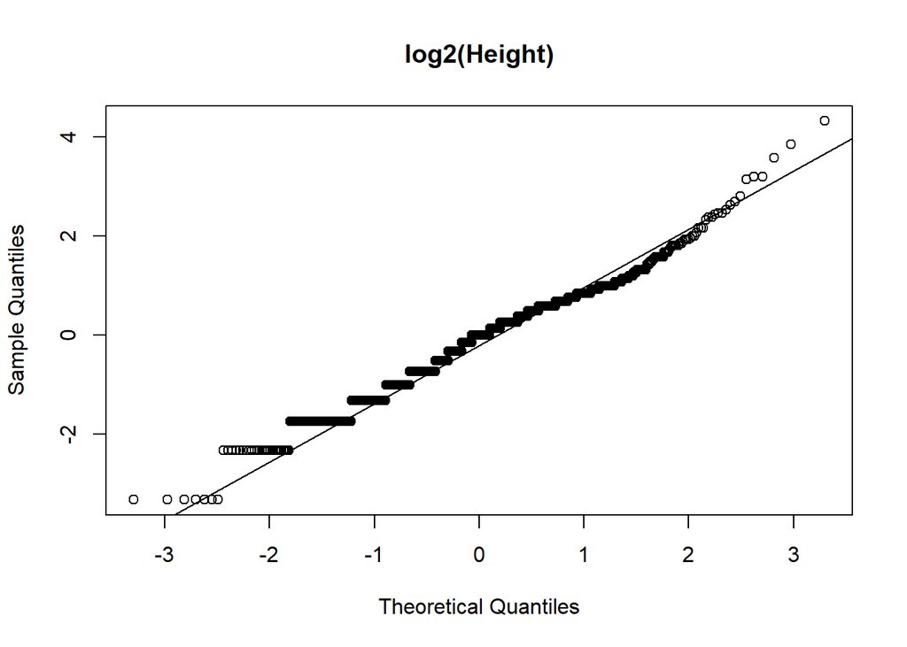

**RESULTS:** We note that both distributions are significantly closer to normality after log transformation.

**CONSEQUENCES:** The transformed versions of the variables might be used for modeling.

From the qqplot it is clear that relatively few distinct values of height are observed in the sample.

**RESULTS:** Extreme values (far from the rest of the distribution) are observed for many variables. There are very few data points for extremely large height or weight; extreme values appear also in the lower and upper part of the distribution for HP, in the upper tails of speed, special defense.

Only 18 Pokémon have a weight greater than 500kg and only 5 Pokémon have a weight greater than 900kg. The 10 most extreme values are shown below, a table reports the details of the 5 with weight above 900 kg.

```r
tail(sort(pokemon$weight_kg), 10)
```

```
##  [1] 750.0 800.0 800.0 820.0 888.0 920.0 950.0 950.0 999.9 999.9
```

```r
db  <-  data.frame(name=pokemon$name[which(pokemon$weight_kg>900)],  weight=pokemon$weight_kg[which(pokemon$weight_kg>900)], special = pokemon$special_status[which(pokemon$weight_kg>900)], image = "")

path_images = paste0("https://img.pokemondb.net/artwork/large/", tolower(pokemon$name[which(pokemon$weight_kg>900)]), ".jpg")



db %>% arrange(desc(weight)) %>%
  kbl(booktabs = T, align = "c") %>%
  kable_styling() %>%
  kable_paper(full_width = T) %>%
  column_spec(4, image = spec_image(path_images[order(-db$weight)], 280, 200) # dimensions of the images
              )
```

name

weight

special

image

Cosmoem

999.9

legendary

Celesteela

999.9

sub-legendary

Groudon

950.0

legendary

Eternatus

950.0

legendary

Mudsdale

920.0

normal

The 10 most extreme values of height are shown below, indicating that the highest values are far from the rest of the distribution.

```r
tail(sort(pokemon$height_m), 10)
```

```
##  [1]  5.8  6.2  6.5  7.0  8.8  9.2  9.2 12.0 14.5 20.0
```

Only 3 Pokémon have more than 10 m of height, 15 more than 5 m, 40 more than 3 m, 101 more than 2 m; only 5% of Pokémon are taller than 2.8 m.

A table reports the details of the 6 with height above 7.5 m.

```r
db  <-  data.frame(name=pokemon$name[which(pokemon$height_m>7.5)],  height = pokemon$height_m[which(pokemon$height_m>7.5)],
special = pokemon$special_status[which(pokemon$height_m>7.5)],
image = "")

path_images = paste0("https://img.pokemondb.net/artwork/large/", tolower(pokemon$name[which(pokemon$height_m>7.5)]), ".jpg")



db %>% arrange(desc(height)) %>%
  kbl(booktabs = T, align = "c") %>%
  kable_styling() %>%
  kable_paper(full_width = T) %>%
  column_spec(4, image = spec_image(path_images[order(-db$height)], 280, 200) # dimensions of the images
              )
```

name

height

special

image

Eternatus

20.0

legendary

Wailord

14.5

normal

Dondozo

12.0

normal

Steelix

9.2

normal

Celesteela

9.2

sub-legendary

Onix

8.8

normal

**RESULTS:** These data descriptions indicate that the estimation of the relationship between height and weight for large values of height will depend heavily on few species.

**RESULTS:** The estimates obtained for large values of height might be very imprecise, due to the extreme values. The estimates for height values larger than 10 m will be based only on 3 data points. Some Pokémon with extreme values in some of the explanatory variables might have large influence on the results.

#### Additional aspects

See the additional IDA report for additional descriptions of aspect related to **evolutionary family** and **type**.

### Multivariable descriptions

**COMMENT:** In multivariable descriptions we evaluate the association between exploratory variables. Special attention is devoted to structural variables (in our example: generation and evolution phase), and to other selected explorations (associations with height, associations among base stats, identification of observations that might be influential).

IDA does not directly explore the association between the exploratory variables and the outcome, which will be addressed during modeling. For this reason we do not present results that explore the association between weight and the exploratory variable (such as scatterplots or summary statistics).

#### Association (between explanatory variables and structural variables)

##### Descriptive statistics of selected variables, by generation

Here we describe the characteristic of the Pokémon by generation.

**CONSEQUENCES:** These generational differences overlap with variables already included in the model (evolutionary phase, special status, gender category, happiness category). Generation is therefore unlikely to explain additional variation in the outcome once these covariates are included, and is not used as a separate covariate in the model.

| Characteristics by generation. | Characteristics by generation. 1 *N=151* | Characteristics by generation. 2 *N=100* | Characteristics by generation. 3 *N=135* | Characteristics by generation. 4 *N=107* | Characteristics by generation. 5 *N=156* | Characteristics by generation. 6 *N=72* | Characteristics by generation. 7 *N=88* | Characteristics by generation. 8 *N=96* | Characteristics by generation. 9 *N=120* |
| --- | --- | --- | --- | --- | --- | --- | --- | --- | --- |
| PokemonPhase_5cat : Baby | 0.00 <sup>0</sup>⁄<sub>151</sub> | 0.08 <sup>8</sup>⁄<sub>100</sub> | 0.01 <sup>2</sup>⁄<sub>135</sub> | 0.07 <sup>7</sup>⁄<sub>107</sub> | 0.00 <sup>0</sup>⁄<sub>156</sub> | 0.00 <sup>0</sup>⁄<sub>72</sub> | 0.00 <sup>0</sup>⁄<sub>88</sub> | 0.00 <sup>0</sup>⁄<sub>96</sub> | 0.00 <sup>0</sup>⁄<sub>120</sub> |
| Base | 0.45 <sup>68</sup>⁄<sub>151</sub> | 0.39 <sup>39</sup>⁄<sub>100</sub> | 0.33 <sup>45</sup>⁄<sub>135</sub> | 0.24 <sup>26</sup>⁄<sub>107</sub> | 0.36 <sup>56</sup>⁄<sub>156</sub> | 0.36 <sup>26</sup>⁄<sub>72</sub> | 0.27 <sup>24</sup>⁄<sub>88</sub> | 0.28 <sup>27</sup>⁄<sub>96</sub> | 0.26 <sup>31</sup>⁄<sub>120</sub> |
| Phase1 | 0.37 <sup>56</sup>⁄<sub>151</sub> | 0.30 <sup>30</sup>⁄<sub>100</sub> | 0.33 <sup>45</sup>⁄<sub>135</sub> | 0.40 <sup>43</sup>⁄<sub>107</sub> | 0.35 <sup>55</sup>⁄<sub>156</sub> | 0.38 <sup>27</sup>⁄<sub>72</sub> | 0.27 <sup>24</sup>⁄<sub>88</sub> | 0.39 <sup>37</sup>⁄<sub>96</sub> | 0.31 <sup>37</sup>⁄<sub>120</sub> |
| Phase2 | 0.11 <sup>16</sup>⁄<sub>151</sub> | 0.10 <sup>10</sup>⁄<sub>100</sub> | 0.11 <sup>15</sup>⁄<sub>135</sub> | 0.11 <sup>12</sup>⁄<sub>107</sub> | 0.12 <sup>19</sup>⁄<sub>156</sub> | 0.11 <sup>8</sup>⁄<sub>72</sub> | 0.10 <sup>9</sup>⁄<sub>88</sub> | 0.11 <sup>11</sup>⁄<sub>96</sub> | 0.09 <sup>11</sup>⁄<sub>120</sub> |
| NotEvolving | 0.07 <sup>11</sup>⁄<sub>151</sub> | 0.13 <sup>13</sup>⁄<sub>100</sub> | 0.21 <sup>28</sup>⁄<sub>135</sub> | 0.18 <sup>19</sup>⁄<sub>107</sub> | 0.17 <sup>26</sup>⁄<sub>156</sub> | 0.15 <sup>11</sup>⁄<sub>72</sub> | 0.35 <sup>31</sup>⁄<sub>88</sub> | 0.22 <sup>21</sup>⁄<sub>96</sub> | 0.34 <sup>41</sup>⁄<sub>120</sub> |
| height_m | 0.700 1.000 1.500 1.195 ± 0.963 | 0.600 0.900 1.400 1.163 ± 1.083 | 0.600 1.000 1.500 1.230 ± 1.478 | 0.500 1.000 1.400 1.134 ± 0.893 | 0.575 1.000 1.400 1.032 ± 0.626 | 0.475 0.800 1.500 1.085 ± 0.975 | 0.400 0.900 1.800 1.351 ± 1.425 | 0.400 1.100 1.900 1.444 ± 2.109 | 0.500 1.200 1.650 1.354 ± 1.356 |
| special_status : normal | 0.97 <sup>146</sup>⁄<sub>151</sub> | 0.94 <sup>94</sup>⁄<sub>100</sub> | 0.93 <sup>125</sup>⁄<sub>135</sub> | 0.87 <sup>93</sup>⁄<sub>107</sub> | 0.92 <sup>143</sup>⁄<sub>156</sub> | 0.92 <sup>66</sup>⁄<sub>72</sub> | 0.69 <sup>61</sup>⁄<sub>88</sub> | 0.88 <sup>84</sup>⁄<sub>96</sub> | 0.90 <sup>108</sup>⁄<sub>120</sub> |
| sub-legendary | 0.02 <sup>3</sup>⁄<sub>151</sub> | 0.03 <sup>3</sup>⁄<sub>100</sub> | 0.04 <sup>5</sup>⁄<sub>135</sub> | 0.06 <sup>6</sup>⁄<sub>107</sub> | 0.04 <sup>6</sup>⁄<sub>156</sub> | 0.00 <sup>0</sup>⁄<sub>72</sub> | 0.19 <sup>17</sup>⁄<sub>88</sub> | 0.07 <sup>7</sup>⁄<sub>96</sub> | 0.03 <sup>4</sup>⁄<sub>120</sub> |
| legendary | 0.01 <sup>1</sup>⁄<sub>151</sub> | 0.02 <sup>2</sup>⁄<sub>100</sub> | 0.02 <sup>3</sup>⁄<sub>135</sub> | 0.03 <sup>3</sup>⁄<sub>107</sub> | 0.02 <sup>3</sup>⁄<sub>156</sub> | 0.04 <sup>3</sup>⁄<sub>72</sub> | 0.06 <sup>5</sup>⁄<sub>88</sub> | 0.04 <sup>4</sup>⁄<sub>96</sub> | 0.06 <sup>7</sup>⁄<sub>120</sub> |
| mythical | 0.01 <sup>1</sup>⁄<sub>151</sub> | 0.01 <sup>1</sup>⁄<sub>100</sub> | 0.01 <sup>2</sup>⁄<sub>135</sub> | 0.05 <sup>5</sup>⁄<sub>107</sub> | 0.03 <sup>4</sup>⁄<sub>156</sub> | 0.04 <sup>3</sup>⁄<sub>72</sub> | 0.06 <sup>5</sup>⁄<sub>88</sub> | 0.01 <sup>1</sup>⁄<sub>96</sub> | 0.01 <sup>1</sup>⁄<sub>120</sub> |
| hp | 45.0 60.0 80.0 64.2 ± 28.6 | 50.0 67.5 86.2 71.0 ± 31.2 | 50.0 61.0 80.0 65.7 ± 25.2 | 57.5 70.0 85.0 73.1 ± 24.7 | 55.0 70.0 80.0 70.3 ± 21.6 | 52.2 65.5 80.5 68.9 ± 21.7 | 51.8 68.0 80.0 71.0 ± 28.1 | 55.8 70.0 90.0 72.8 ± 27.5 | 55.8 77.0 90.0 77.4 ± 28.2 |
| attack | 51.0 70.0 92.0 72.9 ± 26.8 | 49.8 67.5 85.0 68.3 ± 28.4 | 50.0 70.0 90.0 73.1 ± 30.4 | 60.0 80.0 100.0 80.2 ± 30.9 | 55.0 77.5 100.0 81.0 ± 29.4 | 52.0 69.0 90.5 72.5 ± 25.6 | 60.0 76.5 112.2 84.8 ± 32.9 | 60.0 85.0 107.8 82.9 ± 30.8 | 60.0 79.5 103.5 82.4 ± 29.3 |
| defense | 50.0 65.0 84.0 68.2 ± 26.9 | 45.0 65.0 85.0 69.7 ± 35.2 | 46.5 63.0 84.0 69.0 ± 31.1 | 50.0 70.0 97.5 75.1 ± 30.6 | 50.0 70.0 85.0 71.2 ± 23.0 | 53.8 67.5 88.0 75.1 ± 31.3 | 54.8 75.0 95.0 78.7 ± 32.9 | 53.8 69.5 95.0 73.3 ± 26.9 | 60.0 75.0 95.5 76.8 ± 27.8 |
| sp_attack | 45.0 65.0 87.5 67.1 ± 28.5 | 40.0 64.0 85.0 64.5 ± 25.6 | 48.5 65.0 90.0 67.9 ± 28.3 | 50.0 69.0 93.0 73.3 ± 31.2 | 45.0 61.5 90.0 69.2 ± 29.8 | 50.0 66.0 91.8 72.5 ± 28.0 | 50.0 70.0 95.0 75.0 ± 33.8 | 50.0 65.0 90.0 71.6 ± 29.4 | 50.0 65.0 91.2 72.9 ± 31.5 |
| sp_defense | 49.0 65.0 80.0 66.1 ± 24.2 | 50.0 65.0 86.2 72.3 ± 31.5 | 50.0 60.0 81.0 66.5 ± 28.5 | 52.0 70.0 95.0 74.4 ± 27.6 | 50.0 65.0 80.0 67.3 ± 21.9 | 54.8 69.5 89.2 74.6 ± 30.4 | 50.0 73.0 95.0 74.6 ± 28.6 | 50.0 70.0 85.0 69.7 ± 24.0 | 55.0 70.0 88.2 72.5 ± 24.6 |
| speed | 46.5 70.0 90.0 69.1 ± 27.0 | 40.0 60.0 85.0 61.4 ± 27.2 | 44.0 60.0 80.0 61.6 ± 26.9 | 45.5 70.0 90.5 69.5 ± 27.6 | 45.0 64.5 90.5 66.6 ± 28.2 | 47.5 60.0 78.5 65.7 ± 25.9 | 41.5 60.0 85.0 65.4 ± 30.9 | 45.0 68.0 85.0 68.9 ± 33.9 | 50.0 75.0 95.8 75.5 ± 29.4 |
| total | 320.0 405.0 490.0 407.6 ± 99.9 | 319.5 415.0 492.5 407.2 ± 112.5 | 303.5 410.0 475.0 403.7 ± 115.6 | 337.0 480.0 525.0 445.6 ± 117.2 | 322.2 445.5 498.0 425.8 ± 102.5 | 333.8 450.0 501.8 429.3 ± 111.7 | 339.5 480.0 547.5 449.4 ± 119.2 | 326.2 481.5 510.0 439.2 ± 116.3 | 347.5 488.5 555.0 457.4 ± 116.6 |
| catch_rate | 45.0 75.0 190.0 106.2 ± 77.1 | 45.0 60.0 120.0 91.9 ± 71.7 | 45.0 90.0 190.0 113.4 ± 83.8 | 45.0 45.0 120.0 78.9 ± 69.5 | 45.0 75.0 190.0 103.1 ± 76.6 | 45.0 62.5 165.0 100.4 ± 72.5 | 45.0 45.0 105.0 78.7 ± 71.5 | 45.0 45.0 120.0 92.2 ± 81.5 | 28.8 45.0 120.0 77.8 ± 70.7 |
| gender_cat : Equal | 0.60 <sup>91</sup>⁄<sub>151</sub> | 0.67 <sup>67</sup>⁄<sub>100</sub> | 0.70 <sup>95</sup>⁄<sub>135</sub> | 0.55 <sup>59</sup>⁄<sub>107</sub> | 0.64 <sup>100</sup>⁄<sub>156</sub> | 0.64 <sup>46</sup>⁄<sub>72</sub> | 0.49 <sup>43</sup>⁄<sub>88</sub> | 0.61 <sup>59</sup>⁄<sub>96</sub> | 0.59 <sup>71</sup>⁄<sub>120</sub> |
| Mostly female | 0.08 <sup>12</sup>⁄<sub>151</sub> | 0.08 <sup>8</sup>⁄<sub>100</sub> | 0.04 <sup>6</sup>⁄<sub>135</sub> | 0.07 <sup>7</sup>⁄<sub>107</sub> | 0.06 <sup>9</sup>⁄<sub>156</sub> | 0.07 <sup>5</sup>⁄<sub>72</sub> | 0.07 <sup>6</sup>⁄<sub>88</sub> | 0.07 <sup>7</sup>⁄<sub>96</sub> | 0.03 <sup>4</sup>⁄<sub>120</sub> |
| Mostly male | 0.23 <sup>35</sup>⁄<sub>151</sub> | 0.17 <sup>17</sup>⁄<sub>100</sub> | 0.13 <sup>18</sup>⁄<sub>135</sub> | 0.22 <sup>24</sup>⁄<sub>107</sub> | 0.20 <sup>31</sup>⁄<sub>156</sub> | 0.19 <sup>14</sup>⁄<sub>72</sub> | 0.11 <sup>10</sup>⁄<sub>88</sub> | 0.15 <sup>14</sup>⁄<sub>96</sub> | 0.11 <sup>13</sup>⁄<sub>120</sub> |
| Genderless | 0.09 <sup>13</sup>⁄<sub>151</sub> | 0.08 <sup>8</sup>⁄<sub>100</sub> | 0.12 <sup>16</sup>⁄<sub>135</sub> | 0.16 <sup>17</sup>⁄<sub>107</sub> | 0.10 <sup>16</sup>⁄<sub>156</sub> | 0.10 <sup>7</sup>⁄<sub>72</sub> | 0.33 <sup>29</sup>⁄<sub>88</sub> | 0.17 <sup>16</sup>⁄<sub>96</sub> | 0.27 <sup>32</sup>⁄<sub>120</sub> |
| happiness_cat : Happy | 0.03 <sup>4</sup>⁄<sub>151</sub> | 0.03 <sup>3</sup>⁄<sub>100</sub> | 0.02 <sup>3</sup>⁄<sub>135</sub> | 0.11 <sup>12</sup>⁄<sub>107</sub> | 0.04 <sup>7</sup>⁄<sub>156</sub> | 0.03 <sup>2</sup>⁄<sub>72</sub> | 0.00 <sup>0</sup>⁄<sub>88</sub> | 0.03 <sup>3</sup>⁄<sub>96</sub> | 0.00 <sup>0</sup>⁄<sub>120</sub> |
| Normal | 0.93 <sup>140</sup>⁄<sub>151</sub> | 0.83 <sup>83</sup>⁄<sub>100</sub> | 0.76 <sup>103</sup>⁄<sub>135</sub> | 0.75 <sup>80</sup>⁄<sub>107</sub> | 0.83 <sup>130</sup>⁄<sub>156</sub> | 0.89 <sup>64</sup>⁄<sub>72</sub> | 0.74 <sup>65</sup>⁄<sub>88</sub> | 0.89 <sup>85</sup>⁄<sub>96</sub> | 0.71 <sup>85</sup>⁄<sub>120</sub> |
| Unhappy | 0.05 <sup>7</sup>⁄<sub>151</sub> | 0.14 <sup>14</sup>⁄<sub>100</sub> | 0.21 <sup>29</sup>⁄<sub>135</sub> | 0.14 <sup>15</sup>⁄<sub>107</sub> | 0.12 <sup>19</sup>⁄<sub>156</sub> | 0.08 <sup>6</sup>⁄<sub>72</sub> | 0.26 <sup>23</sup>⁄<sub>88</sub> | 0.08 <sup>8</sup>⁄<sub>96</sub> | 0.29 <sup>35</sup>⁄<sub>120</sub> |

*a* *b* *c* represent the lower quartile *a*, the median *b*, and the upper quartile *c* for continuous variables. *x ± s* represents X ± 1 SD.

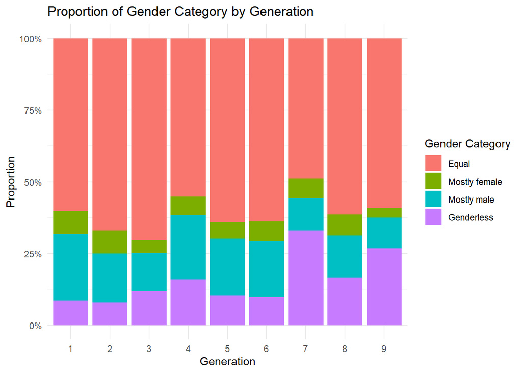

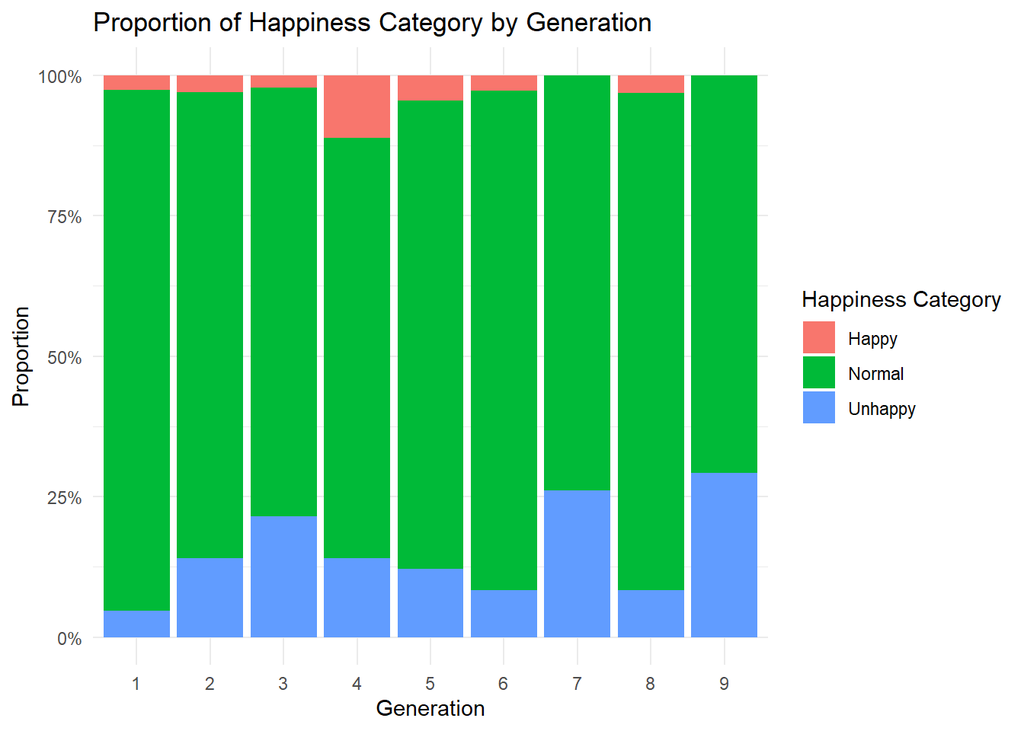

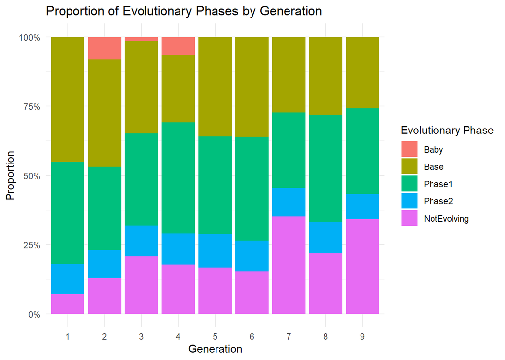

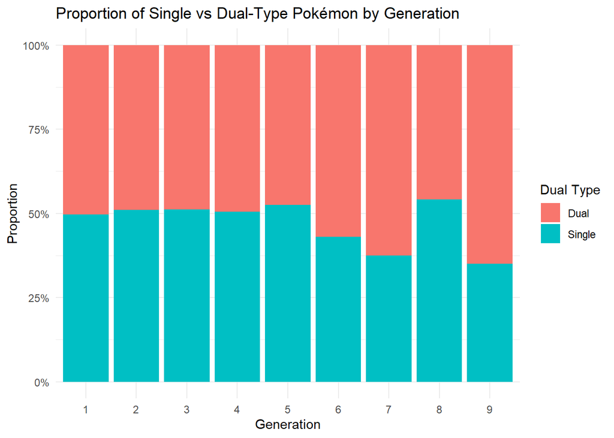

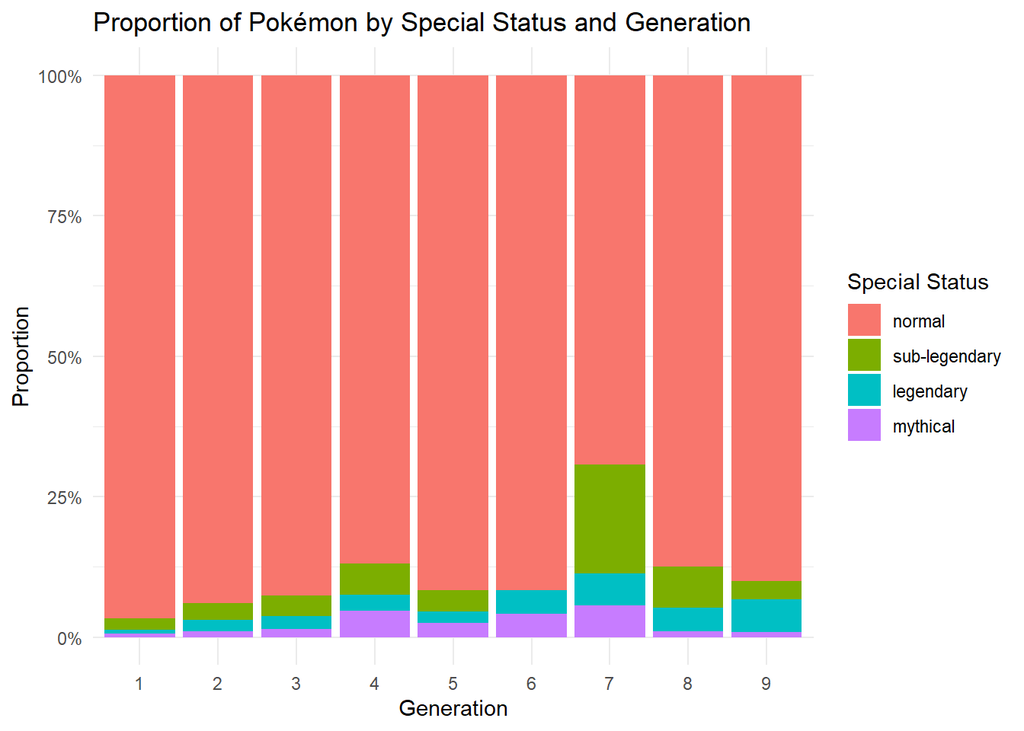